# Tarea_4

## Curso de introducción a la programación con Python

**Autor: Luis Fernando Apáez Álvarez**  
-Curso PyM-  
Tarea 4: Formatos y Plantillas  
Fecha de Entrega: 13 de Agosto del 2022

#### Contenido

Formatos

Plantillas

Adicionalmente

**Descripción:** En esta tarea abordaremos algunos temas adicionales sobre el manejo de las cadenas de texto, en particular, veremos el manejo de formatos y plantillas.

(Tiempo estimado: **60 minutos**)

### Formatos

**Python** posee un sofisticado sistema de formato para las cadenas de texto, el cual nos permite tener variabilidad en los mensajes o impresiones que mostremos. Inicialmente, podemos considerar el siguiente programa para mostrar un mensaje personalizado utilizando un `f string`

```python
# Pedimos al usuario que ingrese su nombre
nombre = input("¿Cuál es su nombre?: ")

# Creamos el mensaje
msj = "cómo estás"

# Mostramos el saludo personalizado
print(f"Hola {nombre}, {msj}")
```

```
¿Cuál es su nombre?: Luis Fernando
Hola Luis Fernando, cómo estás
```

Ahora bien, podemos tomar la idea del código anterior he implementar de nuevo el mismo mensaje personalizado, pero ahora utilizaremos el método `format()`. Para ello comenzaremos creando una cadena de texto

```python
msj = "Hola {}"
print(msj)
```

```
Hola {}
```

Las llaves colocadas en la cadena `msj` siguen la misma idea que las llaves en los `f strings`, esto es, intuitivamente, dentro de dichas llaves podemos colocar variables o código ejecutable, así como vimos en la primer celda de código donde utilizamos el `f string`. Ahora, para el caso de los formatos, no colocaremos de manera directa un valor dentro de dichas llaves, es decir, para este caso la cadena `msj` se quedará así: `"Hola {}"`. Lo que haremos en su lugar para asignar un valor que vaya en vez de dichas llaves, será utilizando el método `format()` sobre dicha cadena. Luego, como parámetro de este método colocamos lo que queremos que vaya en vez de dichas llaves:

```python
# Considerando Hola {}, en vez de dichas llaves
# colocaremos la cadena "Luis Fernando"
print(msj.format("Luis Fernando"))
```

```
Hola Luis Fernando
```

Vemos que las llaves de `"Hola {}"` han sido sustituidas por la cadena `"Luis Fernado"`. Otro ejemplo:

```python
# Considerando Hola {}, en vez de dichas llaves
# colocaremos el resultado de calcular 2 * 4
print(msj.format(2 * 4))
```

```
Hola 8
```

De tal manera, básicamente tenemos

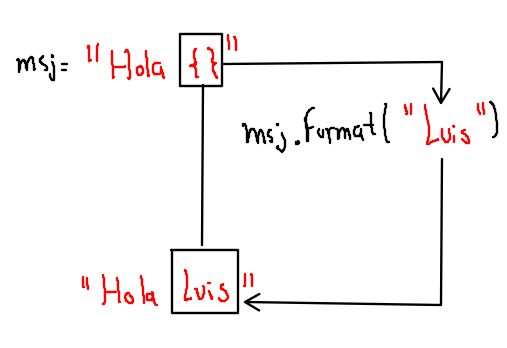

Así, podemos escribir el mismo mensaje personalizado donde utilizamos el `f string`, pero ahora utilizaremos el método `format()`:

```python
# Pedimos al usuario que ingrese su nombre
nombre = input("¿Cuál es su nombre?: ")

# Creamos el mensaje
msj = "Hola {} cómo estás"

# Mostramos el saludo personalizado
# En vez de las llaves de la cadena anterior,
# colocaremos el nombre que el usuario ingreso
print(msj.format(nombre))
```

```
¿Cuál es su nombre?: Luis
Hola Luis cómo estás
```

Con lo cual obtenemos el mismo resultado. Luego, no nos limitamos el el número de parámetros que puede recibir el método `format`, es decir, podemos colocar por ejemplo

```python
# En este caso colocaremos dos llaves
msj2 = "Hola {}, bienvenido. Tienes {} años"
```

así, el método `format()` recibirá ahora dos parámetros, donde el valor del primer parámetro sustituirá a las primeras llaves y el valor del segundo parámetro sustituirá a las segundas llaves, esto es:

```python
print(msj2.format("Luis", 24))
```

```
Hola Luis, bienvenido. Tienes 24 años
```

Y así sucesivamente, podemos agregar más llaves a la cadena, y por ende agregaremos más valores a los parámetros del método `format()`.

**Ejercicio 1:** Completa:

```python
# Utiliza el concepto de f string para mostrar
# el mismo mensaje que se mostro en la anterior celda de codigo,
# donde el nombre y la edad deben ser ingresados por el
# usuario
nombre = input("¿Cuál es tu nombre?: ")
edad = int(_ _ _ )

# Escribe el mismo mensaje que el dado en la celda de
# codigo anterior, pero utiliza un f string
print(_ _ _ )
```

Luego, es natural ver que las llaves que colocamos en las cadenas para utilizar el método `format()` son un tanto ambiguas. Pues, por ejemplo, también podemos escribir

```python
msj2 = "Hola {}, bienvenido. Tienes {} años"
print(msj2.format(24, "Luis"))
```

```
Hola 24, bienvenido. Tienes Luis años
```

Dado que, explícitamente, no estamos indicando que las primeras llaves deben ser para colocar algún nombre y que las segundas deben ser para colocar un número referente a la edad

De tal manera, requerimos mayor precisión o realizar mejores especificaciones. Por ejemplo, de

```
msj2 = "Hola {}, bienvenido. Tienes {} años"
```

nos gustaría especificar que las primeras llaves corresponderán a un nombre y que las segundas corresponderán a la edad. Para ello, podemos colocar una etiqueta (sin comillas) dentro de las llaves, la cual servirá para indicarnos el tipo de información que debemos ingresar en dichas llaves, por ejemplo:

```python
msj3 = "Hola {Nombre}, bienvenido. Tienes {Edad} años"
```

Luego, para la implementación del `format()` escribimos

```python
# Recordemos que:
# Primeras llaves --> Nombre
# Segundas llaves --> Edad

# Por ello:
# Primer parametro del format corresponde a Nombre
# Segundo parametro del format corresponde a Edad
print(msj3.format(Nombre = "Luis", Edad = 24))
```

```
Hola Luis, bienvenido. Tienes 24 años
```

Lo cual es una manera más visual y especifica de la información que estamos ingresando en nuestra cadena `msj3`.

**Ejercicio 2:** Crearemos un formulario para generar un ticket de venta en una librería. Para ello

1. El usuario en este caso será el cajero de la librería. Le pediremos al usuario que ingrese cierta información:

```python
# Nombre del libro
nombre_libro = input("Nombre del libro: ")
# Precio
precio_libro = _ _ _
# Codigo
codigo_libro = int(input("Código: "))
# En ultima_edicion debera ingresar True o False
# la funcion eval() convierte cadenas a booleanos
ultima_edicion = eval(input("Ingresa True o False si es (o no) la última edición "))
```

Crearemos un mensaje dependiendo de si el libro es última edición o no, para ello

```python
# Variable auxiliar
edicion = ""
# Caso en que codigo tiene asignado el valor de True
if ultima_edicion :
    edicion = "si es la última edición"
else:
    edicion = "no es la última edición"

# Crearemos una variable total en la cual calcularemos
# el precio + el iva del 16%:
# Completa
total = precio_libro + _ _ _
```

2. Mostraremos el ticket generado, para lo cual mostraremos un mensaje con la información que ingresó el usuario, donde utilizaremos el método `format()`:

```python
# Mensaje a mostrar:

# \ nos permite continuar escribiendo la cadena de texto
# en la siguiente linea de codigo
# \n es un salto de linea pero a la hora de la impresion
# de la cadena
msj_ticket = "Nombre del libro: {Nombre}\nPrecio: {Precio}\n\
Código del libro {Codigo}\nÚltima edición: {Edicion}\n\
Total a pagar: {Total}"

print(msj_ticket)
```

```
Nombre del libro: {Nombre}
Precio: {Precio}
Código del libro {Codigo}
Última edición: {Edicion}
Total a pagar: {Total}
```

Procedemos a utilizar el método `format()` con la información que ingresó el usuario:

```python
# Termina de escribir el siguiente codigo
# no olvides utilizar la variable edicion que generamos
# en el condicional.
print(msj_ticket.format(Nombre = nombre_libro, Precio = precio_libro, _ _ _ _))
```

### Plantillas

Para crear una plantilla deberemos importar la librería `string`, de la cual utilizaremos el método `Template()` para crear nuestra plantilla. Así, comenzamos con

```python
# importacion necesaria y le damos el alias de s
import string as s
```

La idea detrás de las plantillas es muy similar a la idea de los formatos. De esta manera, crearemos una cadena de texto que sirva como plantilla y en vez de escribir, por ejemplo `"Hola {Nombre}"`, escribiremos `"Hola $Nombre"`

Luego, para crear la plantilla, en este caso debemos utilizar el método `Template()` como sigue

```python
# Creamos una variable para almacenar la plantilla
plantilla1 = s.Template("Hola $Nombre")
```

Después, para utilizar dicha plantilla con valores en especifico, utilizaremos el método `substitute()` sobre la plantilla creada:

```python
print(plantilla1.substitute(Nombre = "Luis"))
print("-" * 30)
print(plantilla1.substitute(Nombre = "Lola"))
print("-" * 30)
print(plantilla1.substitute(Nombre = "Mundo"))
```

```
Hola Luis
------------------------------
Hola Lola
------------------------------
Hola Mundo
```

Podemos agregar más valores a nuestras plantillas:

```python
# Creamos una segunda plantilla
plantilla2 = s.Template("Hola $Nombre, de la ciudad $Ciudad, de edad $Edad años")

# Utilizamos dicha plantilla
print(plantilla2.substitute(Nombre = "Luis", Ciudad = "CDMX", Edad = 24))
print("-" * 60)
print(plantilla2.substitute(Nombre = "Lola", Ciudad = "CDMX", Edad = 84))
```

```
Hola Luis, de la ciudad CDMX, de edad 24 años
------------------------------------------------------------
Hola Lola, de la ciudad CDMX, de edad 84 años
```

**Ejercicio 3:** Considerando la plantilla que hicimos sobre un ticket de venta utilizando el método `format()`. Esta vez, lo que deberás hacer es generar el mismo ticket de venta pero ahora utilizarás el método `Template()` para crear la plantilla, y el método `substitute()` para crear un ticket en particular.

```python
# ESCRIBE TU CODIGO AQUI:
# .
# .
# .
# .
```

### Adicionalmente

Lo siguiente sólo representa un poco de teoría extra. Así, si llegaste hasta aquí significa que has acabado ya tu tarea.

Con el método `format()` podemos crear espacios disponibles para mostrar nuestras cadenas de texto, por ejemplo

```python
# Para mostrar visualmente los espacios que se crean
# podemos colocar | al inicio y fin de los espacios
# creados
# Creamos en total 33 espacios disponibles entre los | |
# para lo cual utilizamos {:33}
print("|{:33}|".format("Hola Mundo"))
print("|{:33}|".format("  :D"))
print("|{:33}|".format(" "))
print("|{:33}|".format("Estos son 33 espacios disponibles"))

# en cambio, utilizamos -
print("-{:33}-".format("Hola Mundo"))

# en cambio, utilizamos *
print("*{:33}*".format("Hola Mundo"))

# o no utilizamos ningun caracter
print("{:33}".format("Hola Mundo"))
```

```
|Hola Mundo                       |
|  :D                             |
|                                 |
|Estos son 33 espacios disponibles|
-Hola Mundo                       -
*Hola Mundo                       *
Hola Mundo
```

Y podemos comprobar que, en efecto, se han creado los 33 espacios:

```python
print(len("Estos son 33 espacios disponibles"))
```

```
33
```

De tal manera, podemos mostrar algo como

```python
nombre = input("Ingrese su nombre: ")
edad = int(input("Ingrese su edad: "))
msj = "Hola {Nombre}, tienes {Edad} años"

# Damos el formato y guardamos dicho mensaje en una
# variable denominada msj_format
msj_format = msj.format(Nombre = nombre, Edad = edad)

# Luego, a dicho mensaje le daremos un contorno
# utilizando | |
print("|{:50}|".format(msj_format))
```

```
Ingrese su nombre: Luis Fernado
Ingrese su edad: 24
|Hola Luis Fernado , tienes 24 años                |
```

Dado que no podemos saber de manera directa el número de espacios generados, pues los nombres tienen distintas longitudes, entonces simplemente podemos utilizar `{:}` sin especificar un número de espacios a crear. El escribir dicha instrucción, en automático, se hará la adaptación de los espacios pertinentes. Por ejemplo

```python
nombre = input("Ingrese su nombre: ")
edad = int(input("Ingrese su edad: "))
msj = "Hola {Nombre}, tienes {Edad} años"

msj_format = msj.format(Nombre = nombre, Edad = edad)

print("|{:}|".format(msj_format))
```

```
Ingrese su nombre: Luis Fernado
Ingrese su edad: 24
|Hola Luis Fernado, tienes 24 años|
```

O también, considerando por ejemplo

```python
nombre = "Luis Fernado"
edad = 24
msj = "Hola {Nombre}, tienes {Edad} años"
msj_format = msj.format(Nombre = nombre, Edad = edad)

print("|{:50}|".format(msj_format))
```

```
|Hola Luis Fernado, tienes 24 años                 |
```

que nos sobran espacios hasta llegar al último `|`, podemos implementar una alineación de nuestro texto. Para ello ocuparemos:

- `^`: Alinea nuestro texto al centro.
- `<`: Alinea nuestro texto a la izquierda.
- `>`: Alinea nuestro texto a la derecha.

Así, logramos conseguir

```python
nombre = "Luis Fernado"
edad = 24
msj = "Hola {Nombre}, tienes {Edad} años"
msj_format = msj.format(Nombre = nombre, Edad = edad)

# implementamos una alineacion al centro (^):
print("|{:^50}|".format(msj_format))

# implementamos una alineacion a la derecha (>):
print("|{:>50}|".format(msj_format))

# implementamos una alineacion a la izquierda (<):
print("|{:<50}|".format(msj_format))
```

```
|        Hola Luis Fernado, tienes 24 años         |
|                 Hola Luis Fernado, tienes 24 años|
|Hola Luis Fernado, tienes 24 años                 |
```

Por otro lado, podemos crear una función para recabar la información (nombre y edad) de un usuario y crear un mensaje con formato, como la variable `msj_format`. Y además, hacemos que esta función regrese dicho mensaje alineado al centro, para lo cual utilizaremos de nuevo `format()`:

```python
# Definimos la funcion para regresar la informacion
# que el usuario ingresa dandole un formato
# y alineandolo al centro:

def mensaje_format():
    # Informacion del usuario
    nombre = input("Ingrese su nombre: ")
    edad = int(input("Ingrese su edad: "))
    # Mensaje
    msj = "Hola {Nombre}, tienes {Edad} años"
    # Mensaje con formato
    msj_format = msj.format(Nombre = nombre, Edad = edad)
    # Mensaje con formato alineado al centro
    msj_format_alin = "|{:^50}|".format(msj_format)
    # Retornamos esta ultima cadena de texto
    return msj_format_alin
```

Probamos la función anterior:

```python
print(mensaje_format())
```

```
Ingrese su nombre: Luis Fernando
Ingrese su edad: 24
|        Hola Luis Fernando, tienes 24 años        |
```

Podemos jugar con los formatos, por ejemplo, haremos que el mensaje que regresa la función sea vea como

[output not shown]

Para ello:

```python
# Definimos la funcion para regresar la informacion
# que el usuario ingresa dandole un formato
# y alineandolo al centro y con algunas mas cosas

def mensaje_format2():
    # Informacion del usuario
    nombre = input("Ingrese su nombre: ")
    edad = int(input("Ingrese su edad: "))
    # Mensaje
    msj = "Hola {Nombre}, tienes {Edad} años"
    # Mensaje con formato
    msj_format = msj.format(Nombre = nombre, Edad = edad)
    # Mensaje con formato alineado al centro
    # quitamos el 50 para que los espacios se adapten
    # al tamagno del mensaje
    # agregamos los asteriscos
    msj_format_alin = "|{} {:^} {}|".format("*" * 10, msj_format, "*" * 10)
    # Retornamos esta ultima cadena de texto
    return msj_format_alin
```

```python
# Probamos la funcion
print(mensaje_format2())
```

```
Ingrese su nombre: Luis Fernando
Ingrese su edad: 24
|********** Hola Luis Fernando, tienes 24 años **********|
```

De manera similar, podemos cambiar los `input()` de las variables, y a su vez utilizar parámetros en nuestra función

```python
# Definimos la funcion para regresar la informacion
# que el usuario ingresa dandole un formato
# y alineandolo al centro y con algunas mas cosas
# ahora la funcion tiene dos parametros,
# el primero es para ingresar el nombre y el
# segundo es para ingresar la edad

# El resto del codigo permanecera igual
def mensaje_format3(nom, ed):
    # Informacion del usuario
    nombre = nom
    edad = ed
    # Mensaje
    msj = "Hola {Nombre}, tienes {Edad} años"
    # Mensaje con formato
    msj_format = msj.format(Nombre = nombre, Edad = edad)
    # Mensaje con formato alineado al centro
    # quitamos el 50 para que los espacios se adapten
    # al tamagno del mensaje
    # agregamos los asteriscos
    msj_format_alin = "|{} {:^} {}|".format("*" * 10, msj_format, "*" * 10)
    # Retornamos esta ultima cadena de texto
    return msj_format_alin
```

```python
# probamos la funcion
print(mensaje_format3("Luis Fernado", 24))
```

```
|********** Hola Luis Fernado, tienes 24 años **********|
```

```python
# o tambien
print(mensaje_format3("Luis Fernado", 24))
print(mensaje_format3("Carla", 17))
print(mensaje_format3("Lola", 84))
```

```
|********** Hola Luis Fernado, tienes 24 años **********|
|********** Hola Carla, tienes 17 años **********|
|********** Hola Lola, tienes 84 años **********|
```